# Naive Bees Predict Species from Images

## 1. Import Python libraries

[figure not shown]

*A honey bee (Apis).*

Can a machine identify a bee as a honey bee or a bumble bee? These bees have different [behaviors and appearances](https://www.thesca.org/connect/blog/bumblebees-vs-honeybees-what%E2%80%99s-difference-and-why-does-it-matter), but given the variety of backgrounds, positions, and image resolutions, it can be a challenge for machines to tell them apart.

Being able to identify bee species from images is a task that ultimately would allow researchers to more quickly and effectively collect field data. Pollinating bees have critical roles in both ecology and agriculture, and diseases like [colony collapse disorder](http://news.harvard.edu/gazette/story/2015/07/pesticide-found-in-70-percent-of-massachusetts-honey-samples/) threaten these species. Identifying different species of bees in the wild means that we can better understand the prevalence and growth of these important insects.

[figure not shown]

*A bumble bee (Bombus).*

After loading and pre-processing images, this notebook walks through building a model that can automatically detect honey bees and bumble bees.

### Instructions

First, we need to import the Python libraries with which we will work.

- Import the class `Image` from the library `PIL`.
- Import the function `train_test_split` from the `model_selection` module of `sklearn`.
- Import the function `SVC` from the `svm` module of `sklearn`. This is the model we'll use.
- Import the function `accuracy_score` from the `metrics` module of `sklearn`. This is the metric we'll use.

###### HINT

Here's a little help getting the import structure right! Try something like the following:

```
from PIL import Image
from sklearn.model_selection import train_test_split
from sklearn.svm import SVC
from sklearn.metrics import roc_curve, auc, accuracy_score
```

```
BEGIN QUESTION
name: q1
points: 1
```

```python
# used to change filepaths
import os

import matplotlib as mpl
import matplotlib.pyplot as plt
from IPython.display import display
%matplotlib inline

import pandas as pd
import numpy as np

# import Image from PIL
from PIL import Image

from skimage.feature import hog
from skimage.color import rgb2gray

from sklearn.preprocessing import StandardScaler
from sklearn.decomposition import PCA

# import train_test_split from sklearn's model selection module
from sklearn.model_selection import train_test_split

# import SVC from sklearn's svm module
from sklearn.svm import SVC

# import accuracy_score from sklearn's metrics module
from sklearn.metrics import roc_curve, auc, accuracy_score
```

## 2. Display image of each bee type

Now that we have all of our imports ready, it is time to look at some images. We will load our `labels.csv` file into a dataframe called `labels`, where the index is the image name (e.g. an index of 1036 refers to an image named 1036.jpg) and the `genus` column tells us the bee type. `genus` takes the value of either `0.0` (Apis or honey bee) or `1.0` (Bombus or bumble bee).

The function `get_image` converts an index value from the dataframe into a file path where the image is located, opens the image using the [Image](https://pillow.readthedocs.io/en/5.1.x/reference/Image.html) object in Pillow, and then returns the image as a numpy array.

We'll use this function to load the sixth Apis image and then the sixth Bombus image in the dataframe.

### Instructions

Load the dataframe of labels and image names. Using that, display the sixth image of a Bombus (bumble bee).

- Display the first five rows of the labels dataframe using `.head()`.
- Subset the dataframe to just Bombus (i.e. where `genus == 1.0`) and assign the sixth item of the index of the subsetted dataframe to the variable `bombus_row`.
- Call the function `get_image` on `bombus_row` to get the image of the Bombus and display it using `plt.imshow`.

###### HINT

The equivalent operations for Apis are:

```
apis_row = labels[labels.genus == 0.0].index[5]
plt.imshow(get_image(apis_row))
```

To convert these two rows for Bombus, change `genus == 0.0` to `genus == 1.0` and replace `apis_row` with `bombus_row`.

```
BEGIN QUESTION
name: q2
points: 1
```

| id | genus |
| --- | --- |
| 520 | 1.0 |
| 3800 | 1.0 |
| 3289 | 1.0 |
| 2695 | 1.0 |
| 4922 | 1.0 |

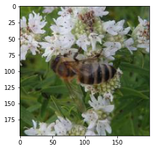

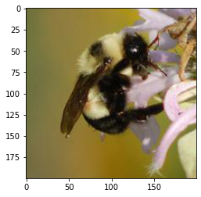

```python
# load the labels using pandas
labels = pd.read_csv("datasets/labels.csv", index_col=0)

# show the first five rows of the dataframe using head
display(labels.head())

def get_image(row_id, root="datasets/"):
    """
    Converts an image number into the file path where the image is located,
    opens the image, and returns the image as a numpy array.
    """
    filename = "{}.jpg".format(row_id)
    file_path = os.path.join(root, filename)
    img = Image.open(file_path)
    return np.array(img)

# subset the dataframe to just Apis (genus is 0.0) get the value of the sixth item in the index
apis_row = labels[labels.genus == 0.0].index[5]

# show the corresponding image of an Apis
plt.imshow(get_image(apis_row))
plt.show()

# subset the dataframe to just Bombus (genus is 1.0) get the value of the sixth item in the index
bombus_row = labels[labels.genus == 1.0].index[5]

# show the corresponding image of a Bombus
plt.imshow(get_image(bombus_row))
plt.show()
```

###### Expected Output

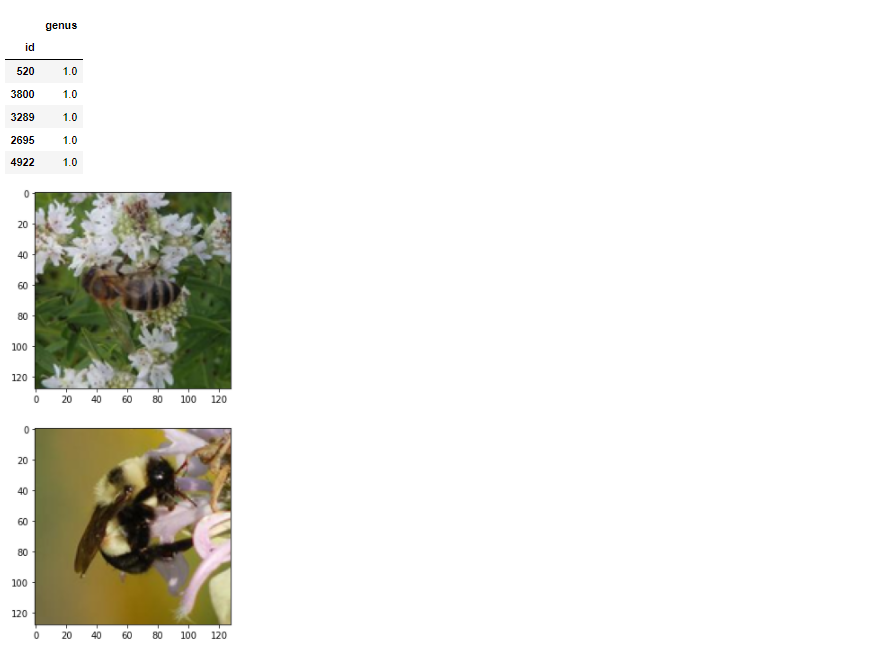

## 3. Image manipulation with rgb2grey

scikit-image has a number of image processing functions built into the library, for example, converting an image to greyscale. The [`rgb2grey`](http://scikit-image.org/docs/dev/api/skimage.color.html#skimage.color.rgb2grey) function computes the luminance of an RGB image using the following formula `Y = 0.2125 R + 0.7154 G + 0.0721 B`.

### Instructions

Now we'll use the `rgb2grey` function to convert our image to `greyscale`.

- Load our bombus image using the `get_image` function and `bombus_row` from the previous cell and assign it to `bombus`.
- Print the shape of the `bombus` image to see that it has three color channels.
- Convert the `bombus` image to `greyscale` using `rgb2grey`.
- Print the shape of the `greyscale` image to see that it only has one channel.

###### HINT

Did you load your `bombus` image with `get_image(bomus_row)`?

Does you convert the `bombus image to greyscale with rgb2grey(bombus)?`

```
BEGIN QUESTION
name: q3
points: 1
```

```
Color bombus image has shape:  (200, 200, 3)
Greyscale bombus image has shape:  (200, 200)
```

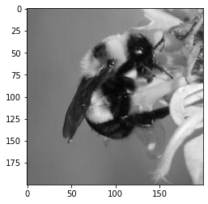

```python
# load a bombus image using our get_image function and bombus_row from the previous cell
bombus = get_image(bombus_row)

# print the shape of the bombus image
print('Color bombus image has shape: ', bombus.shape)

# convert the bombus image to greyscale
grey_bombus = rgb2gray(bombus)

# show the greyscale image
plt.imshow(grey_bombus, cmap=mpl.cm.gray)

# greyscale bombus image only has one channel
print('Greyscale bombus image has shape: ', grey_bombus.shape)
```

###### Expected Output

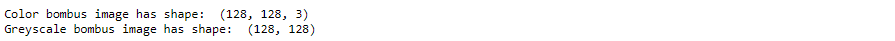

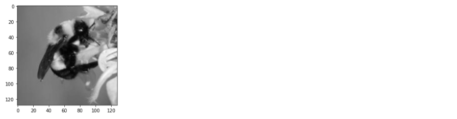

## 4. Histogram of oriented gradients

Now we need to turn these images into something that a machine learning algorithm can understand. Traditional computer vision techniques have relied on mathematical transforms to turn images into useful features. For example, you may want to detect edges of objects in an image, increase the contrast, or filter out particular colors.

We've got a matrix of pixel values, but those don't contain enough interesting information on their own for most algorithms. We need to help the algorithms along by picking out some of the salient features for them using the [histogram of oriented gradients](http://scikit-image.org/docs/dev/auto_examples/features_detection/plot_hog.html) (HOG) descriptor. The idea behind [HOG](https://en.wikipedia.org/wiki/Histogram_of_oriented_gradients) is that an object's shape within an image can be inferred by its edges, and a way to identify edges is by looking at the direction of intensity gradients (i.e. changes in luminescence).

[figure not shown]

An image is divided in a grid fashion into cells, and for the pixels within each cell, a histogram of gradient directions is compiled. To improve invariance to highlights and shadows in an image, cells are block normalized, meaning an intensity value is calculated for a larger region of an image called a block and used to contrast normalize all cell-level histograms within each block. The HOG feature vector for the image is the concatenation of these cell-level histograms.

### Instructions

Using our `greyscale` image, we'll calculate the `HOG` feature vector and image using `hog` from `scikit-image`.

- Call `hog` on the `greyscale` `bombus` image.
- Plot the `hog_image` using `matplotlib`'s `imshow` function.

###### HINT

Remember `hog` takes in a `greyscale` image. We want to use the `greyscale` `bombus` image (`grey_bombus`) from above.

To show the image, try something like `plt.imshow(hog_image, cmap=mpl.cm.gray)`.

```
BEGIN QUESTION
name: q4
points: 1
```

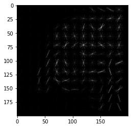

```python
# run HOG using our greyscale bombus image
hog_features, hog_image = hog(grey_bombus,
                              visualize=True,
                              block_norm='L2-Hys',
                              pixels_per_cell=(16, 16))

# show our hog_image with a grey colormap
plt.imshow(hog_image, cmap=mpl.cm.gray)
```

###### Expected Output

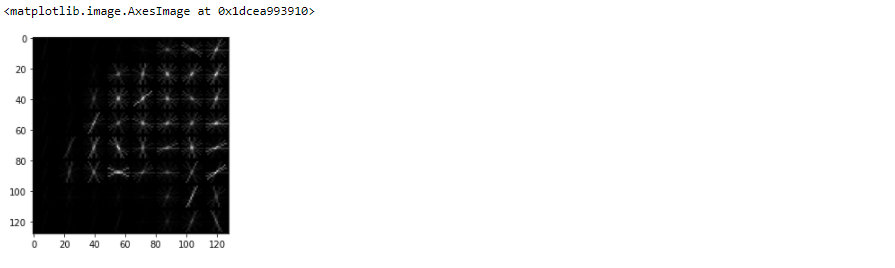

## 5. Create image features and flatten into a single row

Algorithms require data to be in a format where rows correspond to images and columns correspond to features. This means that all the information for a given image needs to be contained in a single row.

We want to provide our model with the raw pixel values from our images as well as the HOG features we just calculated. To do this, we will write a function called `create_features` that combines these two sets of features by flattening the three-dimensional array into a one-dimensional (flat) array.

### Instructions

Write and call a function to create features for and flatten the `bombus image.`

[output not shown]

- Using the method `flatten()`, flatten the original image into a one-dimensional array and assign it to `color_features`.
- Using the function `hstack()`, combine the `color_features` and the `hog_features` arrays and assign it to `flat_features`.

###### HINT

Since `img` is already a numpy array, we can use `flatten` to collapse the three-dimensional array into a one-dimensional one. Does your `color_features` calculation look something like `img.flatten()`?

To combine two arrays sequentially, we can use `np.hstack`. Does your `flat_features` calculation look something like `np.hstack([color_features, hog_features])`?

```
BEGIN QUESTION
name: q5
points: 1
```

```python
def create_features(img):
    # flatten three channel color image
    color_features = np.ndarray.flatten(img)
    # convert image to greyscale
    grey_image = rgb2gray(img)
    # get HOG features from greyscale image
    hog_features = hog(grey_image, block_norm='L2-Hys', pixels_per_cell=(16, 16))
    # combine color and hog features into a single array
    flat_features = np.hstack([color_features,hog_features])
    return flat_features

bombus_features = create_features(bombus)

# print shape of bombus_features
print(bombus_features.shape)
```

```
(128100,)
```

## 6. Loop over images to preprocess

Above we generated a flattened features array for the bombus image. Now it's time to loop over all of our images. We will create features for each image and then stack the flattened features arrays into a big matrix we can pass into our model.

In the `create_feature_matrix` function, we'll do the following:

- Load an image
- Generate a row of features using the `create_features` function above
- Stack the rows into a features matrix

In the resulting features matrix, rows correspond to images and columns to features.

### Instructions

Write a function to generate the features we care about for each image in our dataframe and stack the resulting arrays into a feature matrix.

- Load each image in the dataframe using the `get_image` function from earlier.
- Create the features for each image using the `create_features` function from above.
- Then, use this function to create a feature matrix for our dataframe.

Call `create_feature_matrix` on our `labels` dataframe and assign it to `feature_matrix`.

Note: it may take a few seconds for the cell to finish running as it's calculating the features for all the images in our dataset.

###### HINT

This function combines many of the functions we wrote earlier in the notebook so be sure to reference those.

Keep in mind:

- `get_image` takes in the value of the dataframe index, `img_id`
- `create_features` takes in the color image, `img`
- our dataframe is called `labels`

```
BEGIN QUESTION
name: q6
points: 1
```

```python
def create_feature_matrix(label_dataframe):
    features_list = []

    for img_id in label_dataframe.index:
        # load image
        img = get_image(img_id)
        # get features for image
        image_features = create_features(img)
        features_list.append(image_features)

    # convert list of arrays into a matrix
    feature_matrix = np.array(features_list)
    return feature_matrix

# run create_feature_matrix on our dataframe of images
feature_matrix = create_feature_matrix(labels)

# Inspect Feature Matrix
feature_matrix
```

```
array([[1.29000000e+02, 1.09000000e+02, 1.02000000e+02, ...,
        8.12910211e-02, 8.68682390e-02, 9.77218509e-02],
       [3.60000000e+01, 4.90000000e+01, 2.10000000e+01, ...,
        2.79677819e-02, 1.82294357e-02, 2.49251681e-02],
       [1.60000000e+02, 1.79000000e+02, 1.33000000e+02, ...,
        5.82690255e-03, 5.26410971e-04, 4.78999942e-03],
       ...,
       [8.00000000e+01, 9.50000000e+01, 8.80000000e+01, ...,
        1.81567895e-01, 1.52342685e-01, 6.46092684e-02],
       [1.33000000e+02, 1.64000000e+02, 7.10000000e+01, ...,
        7.44505033e-03, 4.62668879e-03, 2.09801738e-03],
       [7.20000000e+01, 7.20000000e+01, 2.20000000e+01, ...,
        5.33439462e-03, 1.28060379e-02, 9.75740486e-03]])
```

###### Expected Output

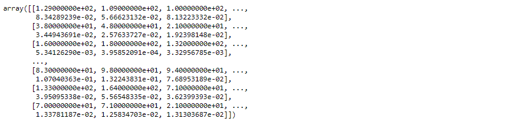

## 7. Scale feature matrix + PCA

Our features aren't quite done yet. Many machine learning methods are built to work best with data that has a mean of 0 and unit variance. Luckily, scikit-learn [provides a simple way](http://scikit-learn.org/stable/modules/generated/sklearn.preprocessing.StandardScaler.html) to rescale your data to work well using `StandardScaler`. They've got a more thorough explanation of why that is in the linked docs.

PCA is a way of linearly transforming the data such that most of the information in the data is contained within a smaller number of features called components. Below is a visual [example](https://towardsdatascience.com/pca-using-python-scikit-learn-e653f8989e60) from an image dataset containing handwritten numbers. The image on the left is the original image with 784 components. We can see that the image on the right (post PCA) captures the shape of the number quite effectively even with only 59 components.

[figure not shown]

### Instructions

Now we'll prepare our features for modeling by first scaling them and then reducing the number of features using `PCA`.

- Print the shape of our `feature_matrix`.
- Use the `fit_transform()` method of the `StandardScaler` object to scale our `feature_matrix` and assign it to `bees_stand`.
- Use the `fit_transform()` method of the `PCA` object to condense `bees_stand`, our standardized feature matrix, and assign it to `bees_pca`.
- Look at the new shape of our final `bees_pca matrix`.

Note: it may take several seconds for the cell to finish running as `PCA` is computationally intensive.

###### HINT

We want to scale `feature_matrix` and then perform `PCA` on `bees_stand` (our standardized feature matrix).

Remember that the syntax for both `StandardScaler` and `PCA`, our two methods, is:

```
x = Method()
transformed_matrix = x.fit_transform(matrix)
```

```
BEGIN QUESTION
name: q7
points: 1
```

```python
# get shape of feature matrix
print('Feature matrix shape is: ', feature_matrix.shape)

# define standard scaler
ss = StandardScaler()
# run this on our feature matrix
bees_stand = ss.fit_transform(feature_matrix)

pca = PCA(n_components=500)
# use fit_transform to run PCA on our standardized matrix
bees_pca = pca.fit_transform(bees_stand)
# look at new shape
print('PCA matrix shape is: ', bees_pca.shape)
```

```
Feature matrix shape is:  (3968, 128100)
PCA matrix shape is:  (3968, 500)
```

###### Expected Output

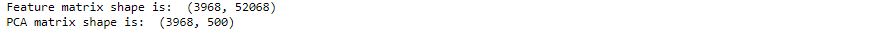

## 8. Split into train and test sets

Now we need to convert our data into train and test sets. We'll use 70% of images as our training data and test our model on the remaining 30%. Scikit-learn's [`train_test_split`](http://scikit-learn.org/stable/modules/generated/sklearn.model_selection.train_test_split.html) function makes this easy.

### Instructions

Split the data into train and test sets for modeling and look at the distribution of `labels` in the train set.

- Call `train_test_split` where `X` is the `bees_pca matrix` (the condensed features matrix that was the result of `PCA`), and `y` is `labels.genus.values`, a series containing the label for each image (from our dataframe).
- Convert `y_train` to a pandas series using `pd.Series` and then call `value_counts` to see the distribution of Apis (`0.0`) and Bombus (`1.0`) labels in our training data.

###### HINT

`train_test_split` has the syntax: `train_test_split(X, y, test_size, random_state)`.

Did you know that you can chain pandas operations together, such as `pd.Series(y_train).value_counts()`?

```
BEGIN QUESTION
name: q8
points: 1
```

```python
## In the projecy, we shall reduce the data size so that the training time is reasonable on our notebook PCs.
# Please do explore if the classification performance will improve if we use use more data to train our machine learnin model.
# samples (indexes) are used to subset our bees_pca and labels to be 512 in size. 256 for each Apis and Bombus classes.
samples = ( np.random.default_rng( 24 ).choice( np.where(labels.genus.values == 0)[0], 256, replace=False).tolist()
            + np.random.default_rng( 48 ).choice(np.where(labels.genus.values == 1)[0], 256, replace=False).tolist() )

X_train, X_test, y_train, y_test = train_test_split(bees_pca[samples],
                                                    labels.genus.values[samples],
                                                    test_size=.3,
                                                    random_state=1234123)

# look at the distrubution of labels in the train set
pd.Series(y_train).value_counts()
```

```
0.0    180
1.0    178
dtype: int64
```

###### Expected Output

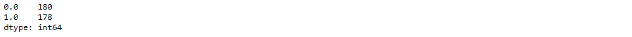

## 9. Train model

It's finally time to build our model! We'll use a [support vector machine](http://scikit-learn.org/stable/modules/svm.html) (SVM), a type of supervised machine learning model used for regression, classification, and outlier detection." An [SVM model](https://en.wikipedia.org/wiki/Support_vector_machine) is a representation of the examples as points in space, mapped so that the examples of the separate categories are divided by a clear gap that is as wide as possible. New examples are then mapped into that same space and predicted to belong to a category based on which side of the gap they fall."

Here's a visualization of the maximum margin separating two classes using an SVM classifier with a linear kernel.

[figure not shown]

Since we have a classification task -- honey or bumble bee -- we will use the support vector classifier (SVC), a type of SVM. We imported this class at the top of the notebook.

### Instructions

Train a support vector classifier (`SVC`).

- Define our model using the `SVC` object with a linear kernel, set `probability=True`, and `random_state=42`.
- Train the model on `X_train` and `y_train` using `.fit()`.
- In this task, we're calculating predictions for each image (i.e. whether an image is a honey bee or a bumble bee). However, we set `probability=True` within our model object `SVC` in order to later be able to look at the probability that each image is a honey or bumble bee. We'll use these probabilities in the next step.
- We set `random_state=42` to ensures that the data is shuffled in a consistent way, meaning our model results won't change if re-run the cell.

###### HINT

Did you define your model with `SVC(kernel='linear', probability=True, random_state=42)`?

Does your model fitting look something like `svm.fit(X_train, y_train)`?

```
BEGIN QUESTION
name: q9
points: 1
```

```python
# define support vector classifier
svm = SVC(kernel='linear',probability=True,random_state=42)

# fit model
svm.fit(X_train,y_train)
```

```
SVC(kernel='linear', probability=True, random_state=42)
```

## 10. Score model

Now we'll use our trained model to generate predictions for our test data. To see how well our model did, we'll calculate the accuracy by comparing our predicted labels for the test set with the true labels in the test set. Accuracy is the number of correct predictions divided by the total number of predictions. Scikit-learn's [`accuracy_score`](http://scikit-learn.org/stable/modules/generated/sklearn.metrics.accuracy_score.html) function will do math for us. Sometimes accuracy can be misleading, but since we have an equal number of honey and bumble bees, it is a useful metric for this problem.

### Instructions

Using our trained model, predict on the test set and calculate accuracy.

- Predict the `labels` for `X_test` using `.predict()`.
- Calculate the accuracy by calling `accuracy_score` on the predicted values from the previous step and the true values (`y_test`).

###### HINT

Did you generate your predictions with `svm.predict(X_test)`?

Remember that `accuracy_score` takes in the true values of `y` (`y_test`) and the predicted values of `y` (`y_pred`).

```
BEGIN QUESTION
name: q10
points: 1
```

```python
# generate predictions
y_pred = svm.predict(X_test)

# calculate accuracy
accuracy = accuracy_score(y_pred,y_test)
print('Model accuracy is: ', accuracy)
```

```
Model accuracy is:  0.5844155844155844
```

###### Expected Output

You are not expected to produce exact answer, but your accuracy should not be far away from it.

## 11. ROC curve + AUC

Above, we used `svm.predict` to predict either `0.0` or `1.0` for each image in `X_test`. Now, we'll use `svm.predict_proba` to get the probability that **each class** is the true label. For example, `predict_proba` returns `[0.46195176, 0.53804824]` for the first image, meaning there is a 46% chance the bee in the image is an Apis (`0.0`) and a 53% chance the bee in the image is a Bombus (`1.0`). Note that the two probabilities for each image always sum to 1.

Using the default settings, probabilities of 0.5 or above are assigned a class label of `1.0` and those below are assigned a `0.0`. However, this threshold can be adjusted. The [receiver operating characteristic curve](https://en.wikipedia.org/wiki/Receiver_operating_characteristic) (ROC curve) plots the false positive rate and true positive rate at different thresholds. ROC curves are judged visually by how close they are to the upper lefthand corner.

The [area under the curve](https://en.wikipedia.org/wiki/Receiver_operating_characteristic#Area_under_the_curve) (AUC) is also calculated, where 1 means every predicted label was correct. Generally, the worst score for AUC is 0.5, which is the performance of a model that randomly guesses. See the scikit-learn documentation for more resources and examples on [ROC curves](http://scikit-learn.org/stable/modules/generated/sklearn.metrics.roc_curve.html) and [AUC](http://scikit-learn.org/stable/modules/generated/sklearn.metrics.auc.html).

### Instructions

Finally, we'll get the predicted probabilities for each image in the test set, plot the `ROC` curve, and calculate the `AUC`.

- Use the `predict_proba` method from our `SVM` model to get the probabilities for `X_test` and assign them to `probabilities`.
- Assign `y_proba` to the `probabilities` for label `1.0` (the second column of `probabilities`).
- Calculate the `AUC` from `false_positive_rate` and `true_positive_rate` and assign it to `roc_auc`.
- Plot the false positive rate on the x axis and the true positive rate on the y axis to show the `ROC` curve.
- We now have a fully trained computer vision model that can be used to identify honey bees and bumble bees in images. The next step in the data science process is to explore improving the model by using more data, adding new features, and trying different methods!

###### HINT

The trickiest part here is selecting only the `probabilities` that each image has a `true` label of `1.0`. Remember that `probabilities` is an array with two columns, where the first column reflects the probability of having a `true` label of `0.0` and the second columns reflects the probability of having a `true` label of `1.0`. To select the second column, we can do `probabilities[:, 1]` and assign this to `y_proba`.

```
BEGIN QUESTION
name: q11
points: 1
```

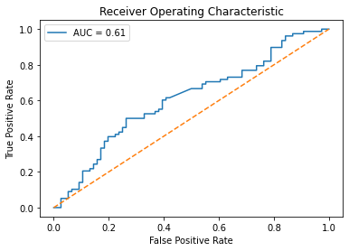

```python
# predict probabilities for X_test using predict_proba
probabilities = svm.predict_proba(X_test)

# select the probabilities for label 1.0
y_proba = probabilities[:,1]

# calculate false positive rate and true positive rate at different thresholds
false_positive_rate, true_positive_rate, thresholds = roc_curve(y_test, y_proba, pos_label=1)

# calculate AUC
roc_auc = auc(false_positive_rate,true_positive_rate)

plt.title('Receiver Operating Characteristic')
# plot the false positive rate on the x axis and the true positive rate on the y axis
roc_plot = plt.plot(false_positive_rate,
                    true_positive_rate,
                    label='AUC = {:0.2f}'.format(roc_auc))

plt.legend(loc=0)
plt.plot([0,1], [0,1], ls='--')
plt.ylabel('True Positive Rate')
plt.xlabel('False Positive Rate');
```

###### Expected Output

You are not expected to produce exact answer, but your AUC should not be far away from it.

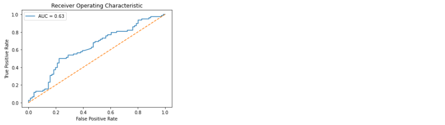